# Predicting the age of abalone from physical measurements

### (c) The Poisson regression model using rings as the response.

```r
rings.glm = glm (rings ~ . , family = poisson, data = new.df)
1-pchisq(rings.glm$deviance,rings.glm$df.residual)
```

```
## [1] 1
```

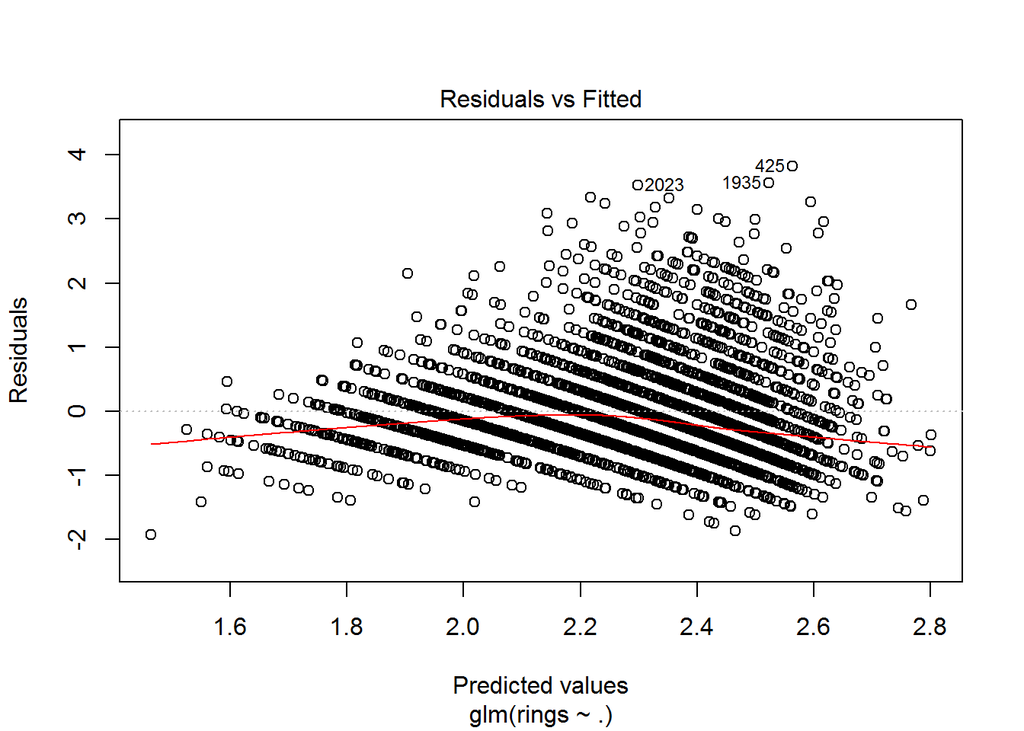

```r
# Poisson assumption is satisfied

plot(rings.glm,which=1)
```

```r
# EOV check is satisfied

anova(rings.glm,test="Chisq")
```

```
## Analysis of Deviance Table
##
## Model: poisson, link: log
##
## Response: rings
##
## Terms added sequentially (first to last)
##
##
##          Df Deviance Resid. Df Resid. Dev  Pr(>Chi)
## NULL                      3671     3692.6
## sex       2   800.06      3669     2892.6 < 2.2e-16 ***
## length    1   563.88      3668     2328.7 < 2.2e-16 ***
## diameter  1    71.79      3667     2256.9 < 2.2e-16 ***
## height    1   139.45      3666     2117.4 < 2.2e-16 ***
## weight    1    25.95      3665     2091.5 3.501e-07 ***
## ---
## Signif. codes:  0 '***' 0.001 '**' 0.01 '*' 0.05 '.' 0.1 ' ' 1
```

```r
summary(rings.glm)
```

```
##
## Call:
## glm(formula = rings ~ ., family = poisson, data = new.df)
##
## Deviance Residuals:
##     Min       1Q   Median       3Q      Max
## -1.9289  -0.5271  -0.1691   0.2696   3.8212
##
## Coefficients:
##              Estimate Std. Error z value Pr(>|z|)
## (Intercept)  1.492172   0.050504  29.545  < 2e-16 ***
## sexI        -0.114751   0.016084  -7.135 9.71e-13 ***
## sexM        -0.009524   0.012188  -0.781  0.43456
## length      -0.890539   0.274765  -3.241  0.00119 **
## diameter     2.030570   0.335717   6.048 1.46e-09 ***
## height       4.232888   0.329577  12.843  < 2e-16 ***
## weight      -0.153173   0.030265  -5.061 4.17e-07 ***
## ---
## Signif. codes:  0 '***' 0.001 '**' 0.01 '*' 0.05 '.' 0.1 ' ' 1
##
## (Dispersion parameter for poisson family taken to be 1)
##
##     Null deviance: 3692.6  on 3671  degrees of freedom
## Residual deviance: 2091.5  on 3665  degrees of freedom
## AIC: 17176
##
## Number of Fisher Scoring iterations: 4
```

Poisson assumption is satisfied. Chi-sqaure test suggest that all regressor are significant in model.

## E. Predict

Using each of the three models, let us predict the number of rings for the observations in `test.df`. Instead of printing out all these predictions, we will rather calculate the mean square error (MSE) for each model over this set of predictions and summarise the relative performance of these models.

```r
ringslm2.pred = predict(rings.lm2, test.df)
ringslm2.mse = mean((ringslm2.pred - test.df$rings)^2, na.rm = TRUE)

logringslm.pred = exp(predict(logrings.lm, test.df))
logringslm.mse = mean((logringslm.pred - test.df$rings)^2, na.rm = TRUE)

ringsglm.pred = exp(predict(rings.glm, test.df))
ringsglm.mse = mean((ringsglm.pred - test.df$rings)^2, na.rm = TRUE)

round(ringslm2.mse,digits = 2)
```

```
## [1] 5.38
```

```r
round(logringslm.mse, digits = 2)
```

```
## [1] 5.53
```

```r
round(ringsglm.mse, digits = 2)
```

```
## [1] 5.56
```

The difference between ordinary regression with rings as response and ordinary regression with log(rings) as response is about 2.7%, it seems ordinary regression with rings as response is performing better on unseen `test.df` data, this is interesting as the variability explained by this model (39%) is about 11% less than oridinary regression with log(rings) as response (50%), still its Mean square value is lower on `test.df`. Poisson regression model is performing poorly on `test.df` as compared to other models.

## F. Analyse using best model

We will now select the model that performed best (with lowest MSE). It makes sense to round the predictions to the nearest whole number. We will plot these rounded predictions versus the actual number of rings for the observations in `test.df`. Also a reference line would be added to indicate predictions that are exactly right.

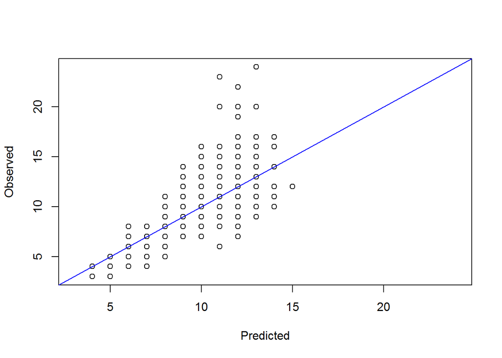

```r
plot(test.df$rings~round(ringslm2.pred), ylim=range(test.df$rings), xlim=range(test.df$rings),xlab= "Predicted", ylab= "Observed")
abline(0,1,col="blue")
```